# Activity 5: Intro to data visualizations

Heather Kropp

#### *ENVST 206: Environmental Data Science, Hamilton College*

## Instructions

There are 10 questions to this activity. Save your answers in word document that you will hand in on Blackboard using a .pdf or .docx extension. Save your file with your last name first in the filename to help me keep track of files for grading. Keep your script file in your GitHub folder and make sure that all changes are pushed to GitHub. Code for all questions should be clearly commented with the question number. You will include a link to your script file as a part of your final question in this activity. The assignment is worth 30 points. Include any plots you make for a question in your answers.

## Learning objectives

#### 1. Plotting fundamentals

#### 2. Learn to use packages in R

#### 3. Learn about different visualization techniques in ggplot2

#### 4. Characterize climate and weather data graphically

## Fundamentals of plotting data

Plots are one of the most useful tools for visualizing weather patterns and long term climate trends. We will work with the NOAA weather data from activity 2 to get more comfortable with making plots in R. You can read in the csv file from the same locations as activity 2 or you may download it again. It will be helpful to set up a vector of the station names that we can commonly refer to.

```r
#read in weather station file from the data folder
datW <- read.csv("/Users/hkropp/Google Drive/teaching/2020/Fall 2020/EnvDataSci/activity/data/activity 5/noaa2011124.csv")
#specify that the name column should be a factor
datW$NAME<- as.factor(datW$NAME)
#set up a vector of all names for each level
nameS <- levels(datW$NAME)
nameS
```

```
## [1] "ABERDEEN, WA US"                  "LIVERMORE, CA US"
## [3] "MANDAN EXPERIMENT STATION, ND US" "MORMON FLAT, AZ US"
## [5] "MORRISVILLE 6 SW, NY US"
```

Let’s start by taking a closer look at precipitation at each site. Just as you did in activity 2, you will want to total up the precipitation that occurred in a year using the aggregate function and sum. If you looked at a histogram of the Morrisville total annual precipitation in activity 2, you may have noticed that one of the data values seemed impossibly low for the area low. If you take a closer look the total precipitation for the year 1978 is calculated to be just 12.7 mm for the entire year. On average, the yearly annual precipitation is about 1,001 mm. This kind of issue is most likely due to most observations missing in the year. You would want to be careful comparing precipitation across sites and years when there is a lot of the year missing. You will also want to remove NAs to accurately count the precipitation observations. You will want to start by putting precipitation in a separate dataframe and ommitting NAs using the **na.omit** function.

```r
#make a dataframe with just precipitation, year, and site name
#remove NA using na.omit
datP <- na.omit(data.frame(NAME=datW$NAME,
                   year=datW$year,
                   PRCP=datW$PRCP))
#total annual precipitation (mm)
precip <- aggregate(datW$PRCP, by=list(datW$NAME,datW$year), FUN="sum", na.rm=TRUE)
#use aggregate to get total annual precipitation
precip <- aggregate(datP$PRCP, by=list(datP$NAME,datP$year), FUN="sum", na.rm=TRUE)
#rename columns
colnames(precip) <- c("NAME","year","totalP")
#add the x column from aggregate looking at the length of observations in each year
precip$ncount <- aggregate(datP$PRCP, by=list(datP$NAME,datP$year), FUN="length")$x
```

If you scroll through the *ncount* column, you’ll see a lot of sites have a full year of observations 365/366, but some sites x years have a very low number of observations such as only 2 or 73 days.

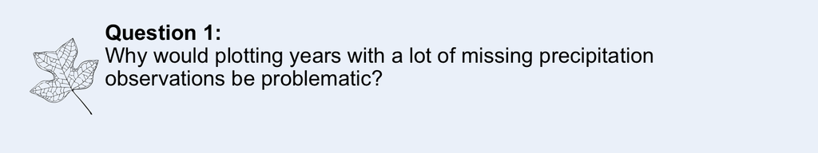

Let’s remove years with too many missing precipitation measurements. There is not always a clear method to consider what might be acceptable amount of missing data. In this case, let’s allow for one day of missing data, but designate any other missing observations as too unreliable.

```r
#make a new dataframe
pr <- precip[precip$ncount >=364, ]
```

```r
#look at only livermore california and morrisville new york preciptiation
ca <- pr[pr$NAME == nameS[2], ]
ny <- pr[pr$NAME == nameS[5], ]
```

Let’s start by looking at the basic plot in R using the California data first.

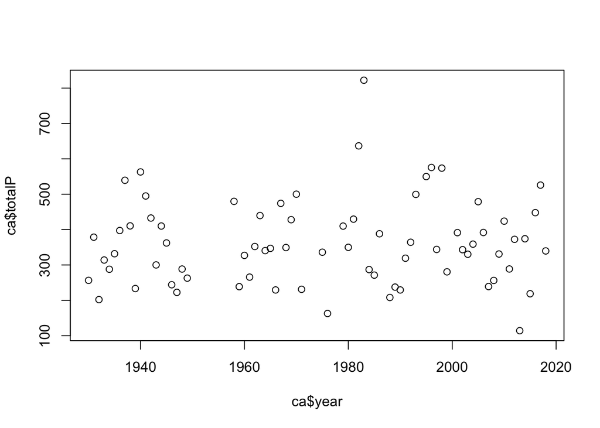

```r
#make a plot of california precip
plot(ca$year, ca$totalP)
```

You’ll notice there are a few aspects of this plot that are difficult to read. There are so many years of observations, it is difficult to track the year to year changes in precipitation so lines would be helpful. It is also a good idea to keep the points since some years may be missing observations. With a few arguments I can improve the plot.

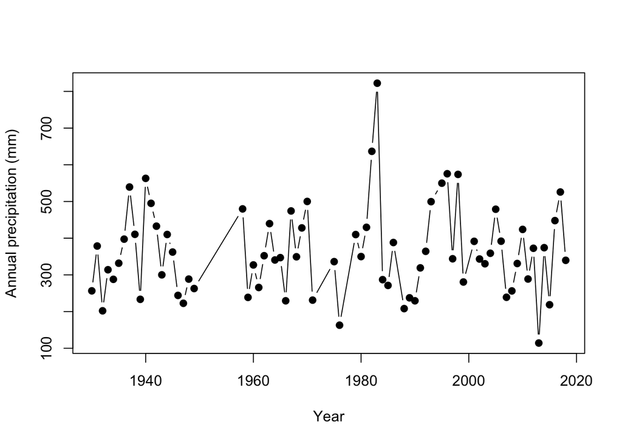

```r
#make a plot of california precip
plot(ca$year, ca$totalP,
     type = "b",
     pch = 19,
     ylab = "Annual precipitation (mm)",
     xlab = "Year")
```

I will also want to improve the axes labeling. You’ll also note that some of the y axis ticks are cut off because the plot window is too small and the labels are flipped in a hard to read direction. R doesn’t offer a lot of axes arguments within the plot function, but we can turn them off and add them separately. You can turn all axes off using the *axes=FALSE* argument or individual axis off. In this case, the x axis looks good so need to change it.

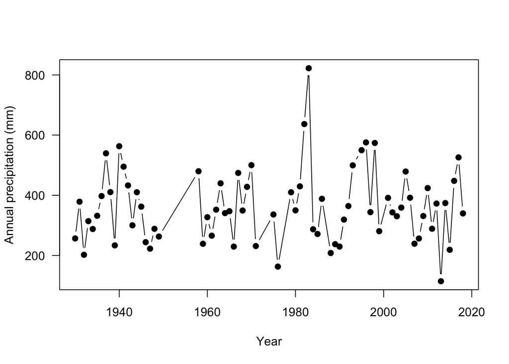

```r
#make a plot of california precip
plot(ca$year, ca$totalP,
     type = "b",
     pch = 19,
     ylab = "Annual precipitation (mm)",
     xlab = "Year",
     yaxt = "n")
#add y axis
#arguments are axis number (1 bottom, 2 left, 3 top, 4 right)
#las = 2 changes the labels to be read in horizontal direction
axis(2, seq(200,800, by=200), las=2 )
```

The plot is looking much better! Now let’s add New York for reference. The **points** function adds points to an existing plot.

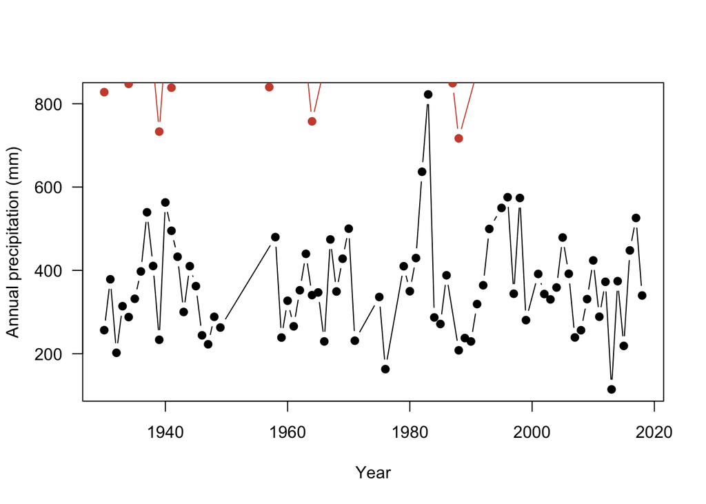

```r
plot(ca$year, ca$totalP,
     type = "b",
     pch = 19,
     ylab = "Annual precipitation (mm)",
     xlab = "Year",
     yaxt = "n")
#add y axis
axis(2, seq(200,800, by=200), las=2 )
#add arizona
points(ny$year, ny$totalP,
     type = "b",
     pch = 19,
     col="tomato3")
```

There are very few observations in New York that fall within the range of the California site. Let’s fix the axes range so that all observations are visible for both sites. Here the *xlim* and *ylim* arguments change the range of the axes. These arguments expect a vector of two numbers: *ylim = c(minimum value, maximum value)*. This tells R the range on the axis to plot.

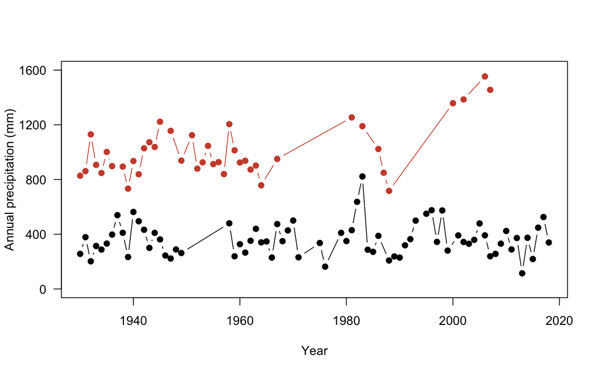

```r
plot(ca$year, ca$totalP,
     type = "b",
     pch = 19,
     ylab = "Annual precipitation (mm)",
     xlab = "Year",
     yaxt = "n",
     ylim =c(0, 1600))
#add y axis
axis(2, seq(0,1600, by=400), las=2 )
#add arizona
points(ny$year, ny$totalP,
     type = "b",
     pch = 19,
     col="tomato3")
```

There is just one last consideration to finish the plot. You need to add a legend to properly label the plot. For the **legend** function, you specify a position for the legend. You can either specify and exact x,y coordinate or you use an argument for a more general position such as: *topleft*, *center*, *bottomright*.

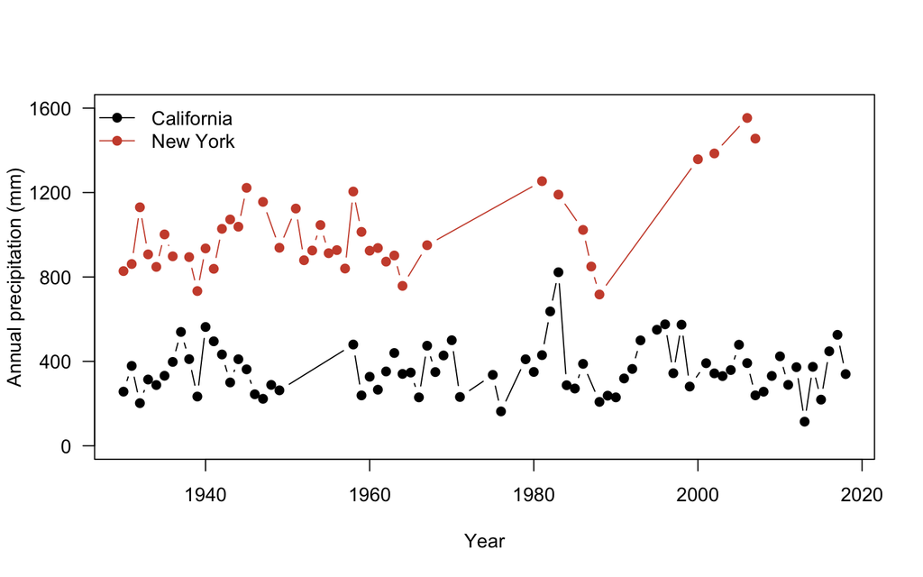

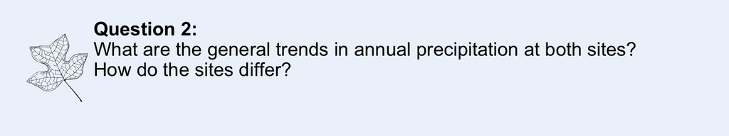

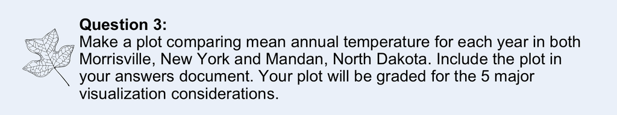

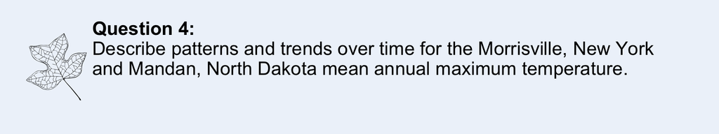

```r
plot(ca$year, ca$totalP,
     type = "b",
     pch = 19,
     ylab = "Annual precipitation (mm)",
     xlab = "Year",
     yaxt = "n",
     ylim =c(0, 1600))
#add y axis
axis(2, seq(0,1600, by=400), las=2 )
#add arizona
points(ny$year, ny$totalP,
     type = "b",
     pch = 19,
     col="tomato3")
#add legend

legend("topleft", #position
       c("California", "New York"), #labels
       col= c("black", "tomato3"), #colors
       pch=19, #point shape
       lwd=1, #line thickness 1, anytime both point & line arguments are given both will be drawn
       bty="n") #always use this argument otherwise an ugly box is drawn
```

## Using packages in R

We have been learning to make plots using the built in functions in R including *plot* and *histogram*. While working with these basic plotting functions is useful, it can take a lot more coding to make a nicer looking figure. **Packages** add additional functions that are not located in the base functions in R. There are a total of 16,336 packages currently available on CRAN that expand the functions available in R. If you were to automatically have all of these packages and their functions loaded in R, it would take up space and too many functions would have the same name. This is why we work with only load the packages needed to run the code in your script in an R session.

The first step in using a package, is to install it to your local computer using the **install.packages** function. **You only need to do run this once for a package unless you use a new computer or re-install R.** You will get a prompt asking what mirror you would like to download from. You may choose any mirror.

```r
install.packages("ggplot2")
```

Once the package is installed, you will need to load the package into your current session using the **library** function. **You will run this every time you start a new R session.**

```r
library(ggplot2)
```

## Plotting in ggplot2

*ggplot2* contains many different functions to make nice looking plots easily. You’ll notice we needed to run many lines of code to make the axes and points look nice. ggplot2 has developed a different plotting syntax than base R. The language of ggplot2 means that you declare the **data** that you are using, the **coordinate system**, and the **geometry** to be used in the plot. The **data** refers to the data source and the **aesthetics**. In the **aesthetics** you define the x, y coordinate specifications and any other information on the size or colors to be used. The **coordinate system** specifies how to plot the data graphically. By default it refers to a **cartesian** coordinate system which simply means plotting on a x,y axis. You don’t need to specify this plotting component if you are making a caresian graph. The **geometry** refers to the shapes/type of plot to be used (ex: bars, boxes, points). You can find a cheat sheet for ggplot2 here: https://github.com/rstudio/cheatsheets/blob/master/data-visualization-2.1.pdf

Let’s get a feel for using ggplot by looking at the annual precipitation across years for all of the sites. You’ll notice that ggplot2 also uses *+* signs to connect multiple functions. This is unique to this type of package.

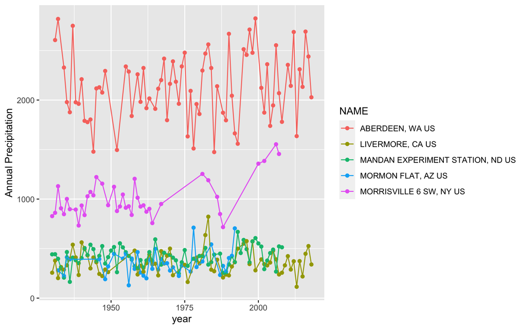

```r
ggplot(data = pr, aes(x = year, y=totalP, color=NAME ) )+ #data for plot
        geom_point()+ #make points at data point
        geom_path()+ #use lines to connect data points
        labs(x="year", y="Annual Precipitation") #make axis labels
```

You’ll notice a legend is automatically made and the y axis labels are in the right direction. There’s just a couple more things. I personally **hate** the grey gridlines. A lot of people like them and that’s fine if you like them. Let’s look at how we can get rid of them by changing the theme.

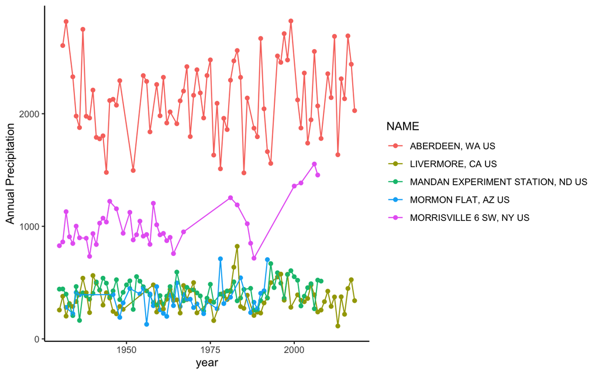

```r
ggplot(data = pr, aes(x = year, y=totalP, color=NAME ) )+ #data for plot
        geom_point()+ #make points at data point
        geom_path()+ #use lines to connect data points
        labs(x="year", y="Annual Precipitation")+ #make axis labels
        theme_classic() #change plot theme
```

It also would be helpful to change the colors and make them semi-transparent so we can see what sites overlap a little better. You can manually change the colors in Rstudio using the *scale_color_manual* setting. Note in R, you can enter colors as color names: such as *“tomato3”*, the hex code, or you can use the rgb() function to designate the amount of red, green, and blue that goes into making a color. There are a lot of color resources online that can help you pick colors. If you search for the color *tomato3* in google, you will get results from color websites that give the hex codes or the red,green, blue composition. In the case of *tomato3*, the hex code is *#CD4F39* and the red, green, blue composition is rgb(0.8, 0.31,0.22). You can find more information on color theory and colors in R here: https://www.nceas.ucsb.edu/sites/default/files/2020-04/colorPaletteCheatsheet.pdf

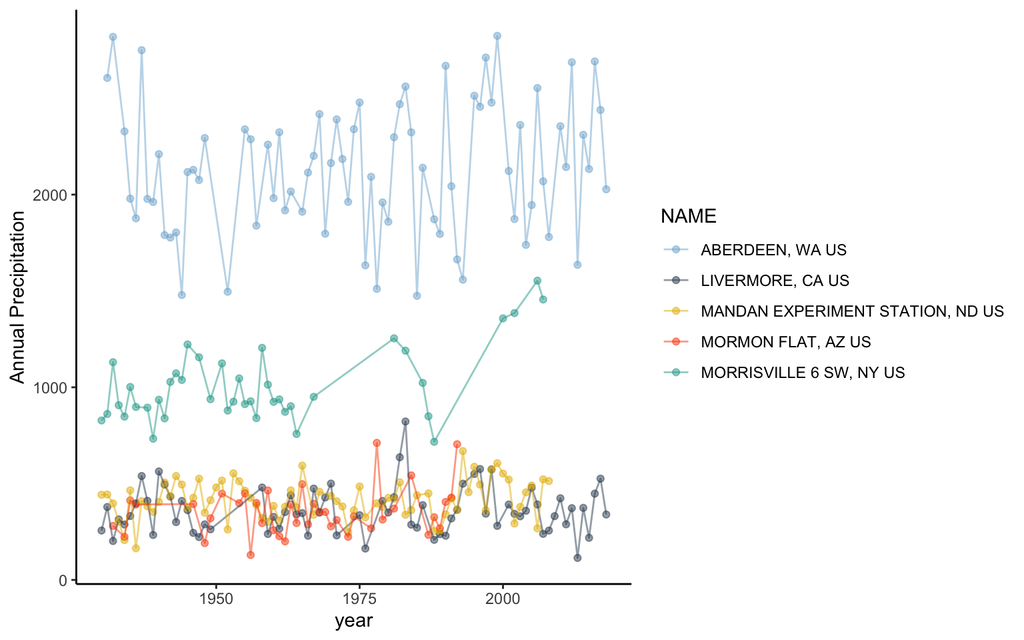

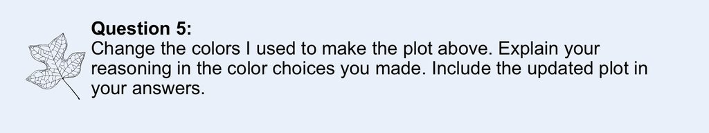

```r
ggplot(data = pr, aes(x = year, y=totalP, color=NAME ) )+
        geom_point(alpha=0.5)+
        geom_path(alpha=0.5)+
        labs(x="year", y="Annual Precipitation")+
        theme_classic()+
        scale_color_manual(values = c("#7FB3D5","#34495E", "#E7B800", "#FC4E07","#26A69A"))
```

## Exploring different visualizations in ggplot2

One of the largest considerations in data visualizations is using the proper type of geometry to display data. Let’s look at making different types of plots in ggplot2.

In class, violin plots were mentioned as a way to display data across categories in a manner that conveys more information than a barplot of means. In ggplot2, violin plots are easy to make. Let’s focus on minimum temperatures for this next part. Let’s take a look at the daily minimum temperatures across each location.

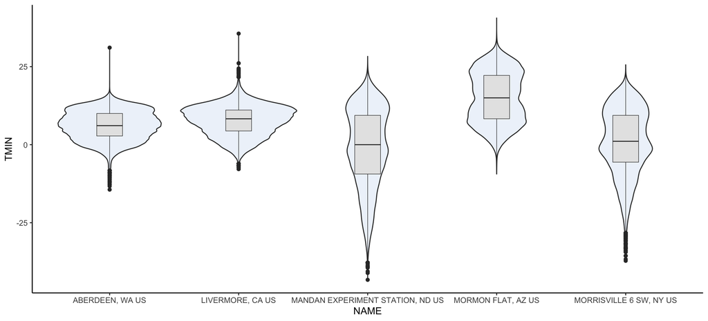

```r
ggplot(data = datW, aes(x=NAME, y=TMIN))+ #look at daily tmin
        geom_violin(fill=rgb(0.933,0.953,0.98))+ #add a violin plot with blue color
        geom_boxplot(width=0.2,size=0.25, fill="grey90")+ #add grey boxplots and make them about 20% smaller than normal with 25% thinner lines than normal
        theme_classic() #git rid of ugly gridlines
```

You may get a warning message that there were non-finite values. That’s all of the NA values in there. No problem that they were removed so you can ignore that message.

Let’s wrap up by looking at one other component of plotting that will be useful. Let’s take a closer look at daily patterns within a year in Morman Flat AZ. 1974 is a fairly complete year so let’s take a closer look.

```r
sub <- datW[datW$NAME == nameS[4] & datW$ year == 1974,]
```

We’ll want to work with dates on the x-axis now. Right now, R thinks the dates are characters. Let’s change that to a date format. There are many ways to format a date: *01-28-1976* and *01/28/1976* both refer to the same date. You have to specify that you want your data to be treated like a date, but you also have to indicate how it is formatted. **as.Date** indicates the vector of data should be considered a date.

```r
#specify date format
#%Y means a four number year
#- indicates that the date uses dashes to seperate
#%m means month
#%d means day
sub$DATE <- as.Date(sub$DATE,"%Y-%m-%d")
```

You can find other types of formatting for dates here: https://www.statmethods.net/input/dates.html

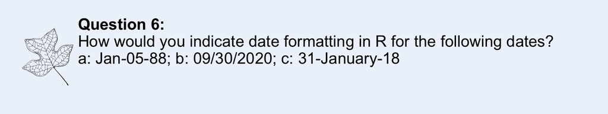

Now when you made plot with date on the x axis in ggplot, you’ll see nicely labeled date information automatically provided.

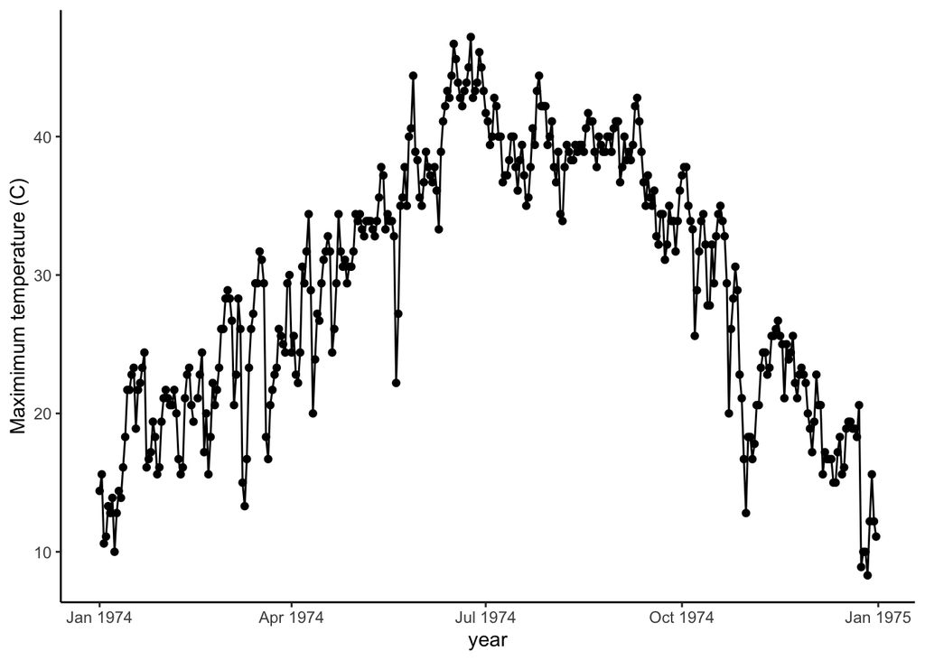

```r
ggplot(data=sub, aes(x=DATE, y=TMAX))+
        geom_point()+
        geom_path()+
        theme_classic()+
        labs(x="year", y="Maximimum temperature (C)")
```

In one last plot example, lets look at a barplot. Barplots are helpful for precipitation since we are often looking at totals for a day or year and in many cases do not have variability in each value.

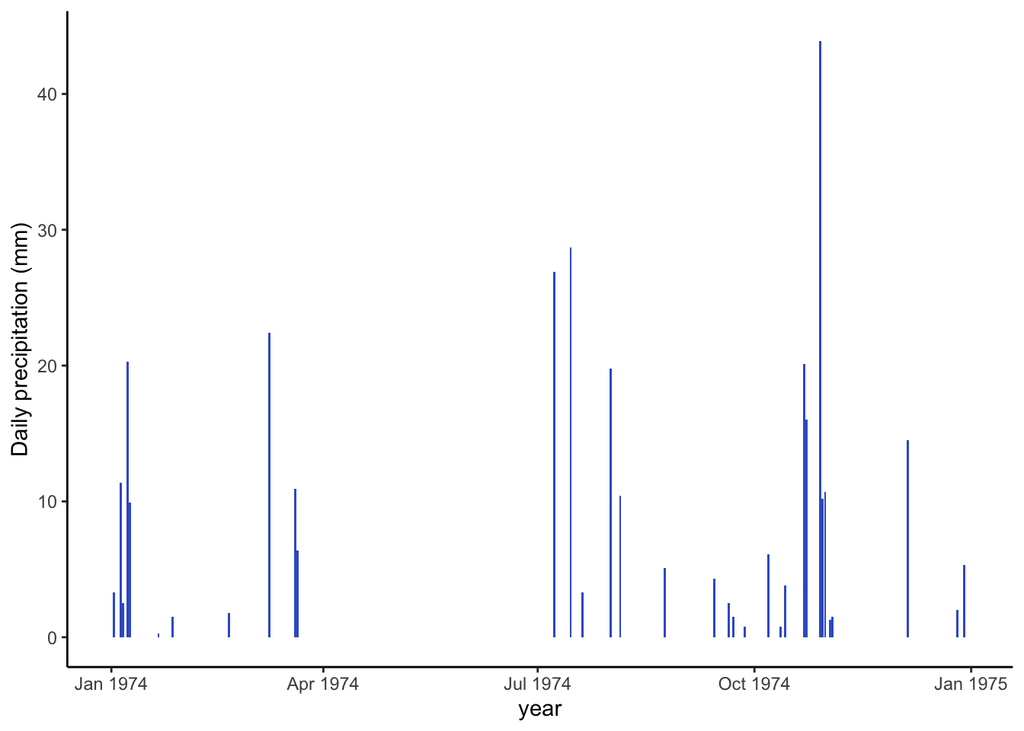

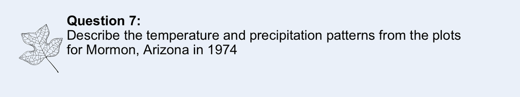

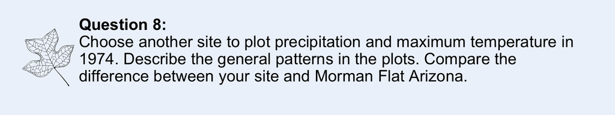

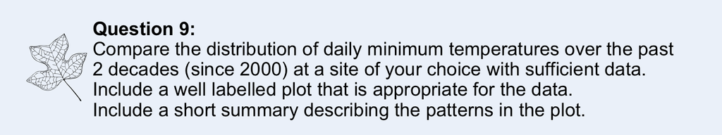

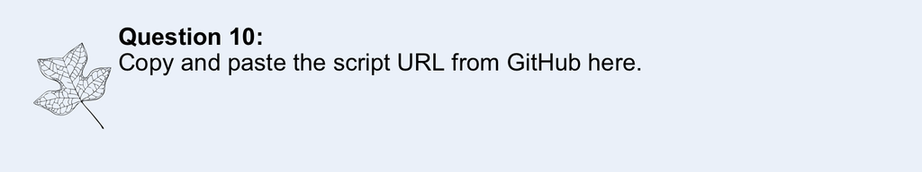

```r
ggplot(data=sub, aes(x=DATE, y=PRCP))+
        geom_col(fill="royalblue3")+
        theme_classic()+
        labs(x="year", y="Daily precipitation (mm)")
```